# Portfolio Optimization Under Estimation Uncertainty

### Bayesian and Bootstrap Analysis of Mean-Variance Portfolio Choice

This analysis studies how estimation uncertainty in expected returns and covariance matrices affects mean-variance portfolio optimization.

Using a small set of liquid ETFs, it compares a standard plug-in approach with Bayesian and bootstrap-based methods.

Context:

The plug-in portfolio uses a single estimate of the return parameters, while the bootstrap and Bayesian approaches incorporate estimation uncertainty by averaging over many plausible parameter realizations.

If the uncertainty-aware portfolios are less concentrated (more diversified) and perform more consistently out of sample, that would support the idea that explicitly modeling estimation uncertainty leads to more robust allocation decisions.

- 0. Set-Up & Load
- 1. Data Prep
- 2. Baseline Plug-In Mean-Variance Optimization
- 3. Bootstrap Analysis of Portfolio Weight Stability
- 4. Bayesian Portfolio Analysis with Markov Chain Monte Carlo (MCMC)
- 5. Comparisons and Posterior Predictions

## 0. Set-Up & Load

Run any necessary codes to enable the script & validate downloaded data.

```python
import pandas as pd
import numpy as np
import matplotlib.pyplot as plt
import seaborn as sns
from pathlib import Path

import cvxpy as cp # optimization package
import pymc as pm # mcmc package
import arviz as az # Bayesian package

sns.set_style("whitegrid")
pd.set_option("display.max_columns", None)
```

[output not shown]

```python
# Set directories
PROJECT_ROOT = Path.cwd().parent
DATA_DIR = PROJECT_ROOT/"data"/"raw"
# PROJECT_ROOT, DATA_DIR
```

```python
# Load 6 ETF data
file_map = {
    "EEM": "eem_us_w.csv",
    "EFA": "efa_us_w.csv",
    "GLD": "gld_us_w.csv",
    "QQQ": "qqq_us_w.csv",
    "SPY": "spy_us_w.csv",
    "TLT": "tlt_us_w.csv"
}

def load_price_file(filename, ticker):
    df = pd.read_csv(DATA_DIR / filename)
    df.columns = [col.strip() for col in df.columns]
    df["Date"] = pd.to_datetime(df["Date"])
    df = df.sort_values("Date").reset_index(drop=True)
    df["Ticker"] = ticker
    return df

price_data = {}

for ticker, filename in file_map.items():
    price_data[ticker] = load_price_file(filename, ticker)

## brief-check on data load
print(list(price_data.keys()))
display(price_data["EEM"].head())
```

```
['EEM', 'EFA', 'GLD', 'QQQ', 'SPY', 'TLT']
```

|  | Date | Open | High | Low | Close | Volume | Ticker |
| --- | --- | --- | --- | --- | --- | --- | --- |
| 0 | 2014-01-05 | 32.6368 | 33.0223 | 31.5176 | 31.6595 | 381140959 | EEM |
| 1 | 2014-01-12 | 31.5324 | 31.8932 | 30.9782 | 31.7760 | 457375166 | EEM |
| 2 | 2014-01-19 | 31.8383 | 31.8813 | 31.3107 | 31.3969 | 384418374 | EEM |
| 3 | 2014-01-26 | 31.5626 | 31.7760 | 30.1432 | 30.1751 | 430818238 | EEM |
| 4 | 2014-02-02 | 30.2144 | 30.3793 | 29.6531 | 30.1348 | 677064509 | EEM |

Data obtained from Stooq (https://stooq.com/).

6 ETFs chosen to keep dataset small, diversified, and easily and universally interpretable.

Downloaded as weekly for 10-year (2014-01-01 to 2023-12-31) + 2 additional years (2024-01-01 to 2025-12-31) for validation.

```python
# Summarize datasets to check for inconsistencies
summary_rows = []

for ticker, df in price_data.items():
    summary_rows.append({
        "Ticker": ticker,
        "Rows": len(df),
        "Start Date": df["Date"].min(),
        "End Date": df["Date"].max()
    })

data_summary = pd.DataFrame(summary_rows).sort_values("Ticker").reset_index(drop=True)
data_summary
```

|  | Ticker | Rows | Start Date | End Date |
| --- | --- | --- | --- | --- |
| 0 | EEM | 627 | 2014-01-05 | 2026-01-04 |
| 1 | EFA | 627 | 2014-01-05 | 2026-01-04 |
| 2 | GLD | 627 | 2014-01-05 | 2026-01-04 |
| 3 | QQQ | 627 | 2014-01-05 | 2026-01-04 |
| 4 | SPY | 627 | 2014-01-05 | 2026-01-04 |
| 5 | TLT | 627 | 2014-01-05 | 2026-01-04 |

All 6 datasets have consistent start and end dates with exact weekly records. Note that the record picks up the end of week record for the chosen start and end-date.

## 1. Data Prep

Combine the 6 ETFs into a single dataset & compute weekly log returns for portfolio analysis.

```python
# Combine all datasets
all_prices = pd.concat(price_data.values(), ignore_index=True)

## brief-check
print(len(all_prices))
display(all_prices.head())
print(all_prices.info())
```

```
3762
```

|  | Date | Open | High | Low | Close | Volume | Ticker |
| --- | --- | --- | --- | --- | --- | --- | --- |
| 0 | 2014-01-05 | 32.6368 | 33.0223 | 31.5176 | 31.6595 | 381140959.0 | EEM |
| 1 | 2014-01-12 | 31.5324 | 31.8932 | 30.9782 | 31.7760 | 457375166.0 | EEM |
| 2 | 2014-01-19 | 31.8383 | 31.8813 | 31.3107 | 31.3969 | 384418374.0 | EEM |
| 3 | 2014-01-26 | 31.5626 | 31.7760 | 30.1432 | 30.1751 | 430818238.0 | EEM |
| 4 | 2014-02-02 | 30.2144 | 30.3793 | 29.6531 | 30.1348 | 677064509.0 | EEM |

```
<class 'pandas.DataFrame'>
RangeIndex: 3762 entries, 0 to 3761
Data columns (total 7 columns):
 #   Column  Non-Null Count  Dtype
---  ------  --------------  -----
 0   Date    3762 non-null   datetime64[us]
 1   Open    3762 non-null   float64
 2   High    3762 non-null   float64
 3   Low     3762 non-null   float64
 4   Close   3762 non-null   float64
 5   Volume  3762 non-null   float64
 6   Ticker  3762 non-null   str
dtypes: datetime64[us](1), float64(5), str(1)
memory usage: 205.9 KB
None
```

No abnormality noted. Successful append.

```python
# Extract necessary columns only
prices_long = all_prices[['Date', 'Ticker', 'Close']].copy()
## sort by date then ticker to show weekly sets
prices_long = prices_long.sort_values(['Date', 'Ticker']).reset_index(drop=True)

# Pivot to wide form: one row per week with tickers as each column
prices_wide = prices_long.pivot(index='Date', columns='Ticker', values='Close')
prices_wide = prices_wide.sort_index()
asset_names = list(prices_wide.columns) # for future usage

display(prices_wide.head())
print(prices_wide.isna().sum()) ## check for any missing values resulted from unsuccessful pivot
```

| Ticker Date | EEM | EFA | GLD | QQQ | SPY | TLT |
| --- | --- | --- | --- | --- | --- | --- |
| 2014-01-05 | 31.6595 | 51.8601 | 119.29 | 78.7689 | 150.255 | 73.2760 |
| 2014-01-12 | 31.7760 | 52.5107 | 120.26 | 79.3719 | 151.280 | 74.8755 |
| 2014-01-19 | 31.3969 | 52.5107 | 120.93 | 79.8971 | 150.857 | 75.6451 |
| 2014-01-26 | 30.1751 | 50.9679 | 122.29 | 78.8584 | 146.944 | 77.1170 |
| 2014-02-02 | 30.1348 | 49.9945 | 120.09 | 78.4299 | 146.359 | 77.6916 |

```
Ticker
EEM    0
EFA    0
GLD    0
QQQ    0
SPY    0
TLT    0
dtype: int64
```

```python
# Calculate log returns: this would work better with some statistical methods
returns = np.log(prices_wide / prices_wide.shift(1)).dropna()

display(returns.head())
display(returns.describe())
```

| Ticker Date | EEM | EFA | GLD | QQQ | SPY | TLT |
| --- | --- | --- | --- | --- | --- | --- |
| 2014-01-12 | 0.003673 | 0.012467 | 0.008099 | 0.007626 | 0.006799 | 0.021594 |
| 2014-01-19 | -0.012002 | 0.000000 | 0.005556 | 0.006595 | -0.002800 | 0.010226 |
| 2014-01-26 | -0.039692 | -0.029821 | 0.011183 | -0.013086 | -0.026281 | 0.019271 |
| 2014-02-02 | -0.001336 | -0.019283 | -0.018154 | -0.005449 | -0.003989 | 0.007423 |
| 2014-02-09 | 0.014034 | 0.023459 | 0.017172 | 0.011939 | 0.008471 | -0.011372 |

| Ticker | EEM | EFA | GLD | QQQ | SPY | TLT |
| --- | --- | --- | --- | --- | --- | --- |
| count | 626.000000 | 626.000000 | 626.000000 | 626.000000 | 626.000000 | 626.000000 |
| mean | 0.000918 | 0.001001 | 0.001926 | 0.003278 | 0.002419 | 0.000257 |
| std | 0.026167 | 0.023228 | 0.019956 | 0.027132 | 0.022875 | 0.019344 |
| min | -0.141886 | -0.154511 | -0.094942 | -0.119503 | -0.157233 | -0.080013 |
| 25% | -0.015366 | -0.010273 | -0.009531 | -0.011978 | -0.008350 | -0.010608 |
| 50% | 0.002422 | 0.002345 | 0.001902 | 0.004908 | 0.003891 | 0.001207 |
| 75% | 0.018332 | 0.014410 | 0.013857 | 0.019480 | 0.014785 | 0.012469 |
| max | 0.087815 | 0.116433 | 0.083096 | 0.091187 | 0.114103 | 0.072789 |

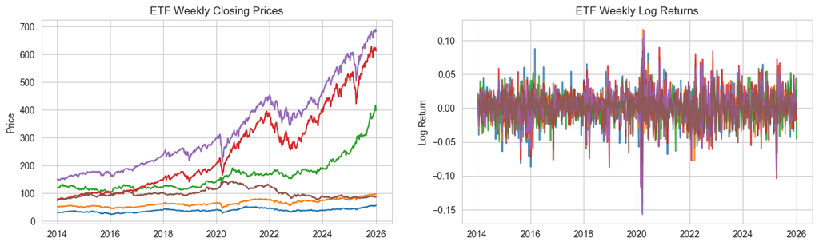

```python
# Simple Visualization to compare simple returns & log returns
fig, axes = plt.subplots(1, 2, figsize=(15, 4))
axes[0].plot(prices_wide)
axes[0].set_title("ETF Weekly Closing Prices")
axes[0].set_ylabel("Price")
axes[1].plot(returns, alpha=0.8)
axes[1].set_title("ETF Weekly Log Returns")
axes[1].set_ylabel("Log Return")
```

```python
# Split Data into Training and Holdout
train_returns = returns.loc["2014-01-01":"2023-12-31"].copy() ## First 10 years (2023 last week ends right on 2023/12/31)
test_returns = returns.loc["2024-01-01":"2026-01-04"].copy() ## Additional 2 years (2025 last week ends on 2026/01/04)

print(train_returns.shape, test_returns.shape)
print("Train Start: \t", train_returns.index.min())
print("Train End: \t", train_returns.index.max())
print("Holdout Start: \t", test_returns.index.min())
print("Holdout End: \t", test_returns.index.max())
```

```
(521, 6) (105, 6)
Train Start: 	 2014-01-12 00:00:00
Train End: 	 2023-12-31 00:00:00
Holdout Start: 	 2024-01-07 00:00:00
Holdout End: 	 2026-01-04 00:00:00
```

## 2. Baseline Plug-In Mean-Variance Optimization

Implement standard plug-in approach to mean-variance portfolio optimization.

Expected returns and covariance matrix are estimated from the training sample & treated as fixed inputs in the optimization.

Define optimizer: simple mean-variance utility

$$\max_{w} \; \mu^\top w - \gamma \, w^\top \Sigma w$$

subject to:

$$\sum_{i=1}^N w_i = 1$$ $$w_i \ge 0, \quad i = 1, \dots, N$$

In simple terms, find weights ($w$) that maximize returns ($\mu$) while penalizing weighted risk ($\Sigma$; covariance) with risk-aversion parameter $\gamma$.

```python
# Calculate means & cov_matrix
mu_hat = train_returns.mean().values
Sigma_hat = train_returns.cov().values # cov_matrix (6x6)

print(mu_hat)
print(Sigma_hat)
```

```
[0.00041353 0.00071707 0.00090519 0.00314981 0.0021802  0.00039302]
[[ 7.24315861e-04  5.17555201e-04  1.14487139e-04  4.93032113e-04
   4.47080776e-04 -3.41625203e-05]
 [ 5.17555201e-04  5.57290959e-04  7.92642704e-05  4.82007612e-04
   4.74223375e-04 -3.09306632e-05]
 [ 1.14487139e-04  7.92642704e-05  3.76171682e-04  4.38642241e-05
   5.31190827e-05  1.37286531e-04]
 [ 4.93032113e-04  4.82007612e-04  4.38642241e-05  7.32606257e-04
   5.79772935e-04 -1.84513900e-05]
 [ 4.47080776e-04  4.74223375e-04  5.31190827e-05  5.79772935e-04
   5.42589443e-04 -4.88432599e-05]
 [-3.41625203e-05 -3.09306632e-05  1.37286531e-04 -1.84513900e-05
  -4.88432599e-05  3.82236071e-04]]
```

```python
# Summarize Means for Overview
mu_summary = pd.DataFrame({
    "Ticker": train_returns.columns,
    "Mean Weekly Log Return": train_returns.mean().values,
    "Weekly Volatility": train_returns.std().values
}).sort_values("Mean Weekly Log Return", ascending=False).reset_index(drop=True)

mu_summary
```

|  | Ticker | Mean Weekly Log Return | Weekly Volatility |
| --- | --- | --- | --- |
| 0 | QQQ | 0.003150 | 0.027067 |
| 1 | SPY | 0.002180 | 0.023294 |
| 2 | GLD | 0.000905 | 0.019395 |
| 3 | EFA | 0.000717 | 0.023607 |
| 4 | EEM | 0.000414 | 0.026913 |
| 5 | TLT | 0.000393 | 0.019551 |

```python
# Create Mean-Variance Optimizer solution function with cvxpy package
def solve_mean_variance_portfolio(mu, Sigma, gamma=10):
    n_assets = len(mu)
    w = cp.Variable(n_assets)

    objective = cp.Maximize(mu @ w - gamma * cp.quad_form(w, Sigma))
    constraints = [
        cp.sum(w) == 1,
        w >= 0
    ]

    problem = cp.Problem(objective, constraints)
    problem.solve()

    return np.array(w.value).flatten() # this solves the optimization probelm & output weights
```

|  | Ticker | Weight |
| --- | --- | --- |
| 0 | TLT | 0.30558 |
| 1 | GLD | 0.28297 |
| 2 | QQQ | 0.22925 |
| 3 | SPY | 0.18220 |
| 4 | EFA | 0.00000 |
| 5 | EEM | 0.00000 |

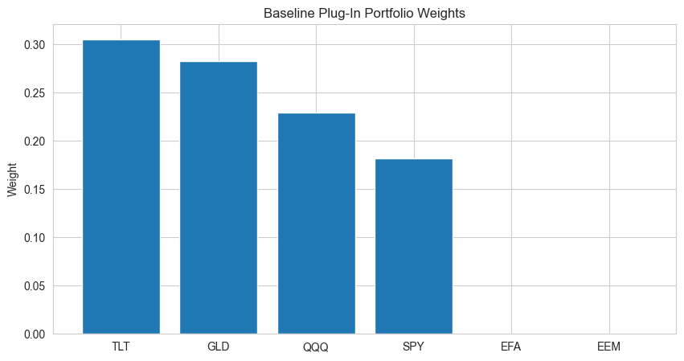

```python
# Calculate baseline weights for plu-in calculations
baseline_weights = solve_mean_variance_portfolio(mu_hat, Sigma_hat, gamma=10) # use gamma 10 as a starting value (rule of thumb)

## summarize above weights
baseline_weight_table = pd.DataFrame({
    "Ticker": train_returns.columns,
    "Weight": baseline_weights
}).sort_values("Weight", ascending=False).reset_index(drop=True)

display(baseline_weight_table.style.format({'Weight': '{:.5f}'}))

# Visualize returns as a bar chart
plt.figure(figsize=(10, 5))
plt.bar(baseline_weight_table["Ticker"], baseline_weight_table["Weight"])
plt.title("Baseline Plug-In Portfolio Weights")
plt.ylabel("Weight")
plt.show()
```

Notice that the optimization solution provided 0 weights for EFA and EEM. This is certainly a possibility within simple mean-variance optimization.

Using these baseline weights, compute portfolio returns for both train and holdout sets.

```python
# Calculate price * weights = returns
baseline_train_portfolio_returns = train_returns.values @ baseline_weights
baseline_test_portfolio_returns = test_returns.values @ baseline_weights


# Create summary of returns
## Summarize return into three metrics
def portfolio_summary_stats(portfolio_returns):
    mean_return = np.mean(portfolio_returns)
    volatility = np.std(portfolio_returns, ddof=1)
    sharpe_ratio = mean_return / volatility
    return {
        "Mean Weekly Return": mean_return,
        "Weekly Volatility": volatility,
        "Sharpe Ratio": sharpe_ratio
    }

## Apply the summary
baseline_train_stats = portfolio_summary_stats(baseline_train_portfolio_returns)
baseline_test_stats = portfolio_summary_stats(baseline_test_portfolio_returns)

## Clean up for display
baseline_overview = pd.DataFrame(
    [baseline_train_stats, baseline_test_stats],
    index=["Train", "Test"]
)

## Add concentration metric to the summary
baseline_concentration = np.sum(baseline_weights ** 2) # use sums of square to capture the diversification across 6 weights
baseline_overview["Weight Concentration"] = baseline_concentration

baseline_overview
```

|  | Mean Weekly Return | Weekly Volatility | Sharpe Ratio | Weight Concentration |
| --- | --- | --- | --- | --- |
| Train | 0.001496 | 0.014059 | 0.106380 | 0.259203 |
| Test | 0.003405 | 0.013106 | 0.259769 | 0.259203 |

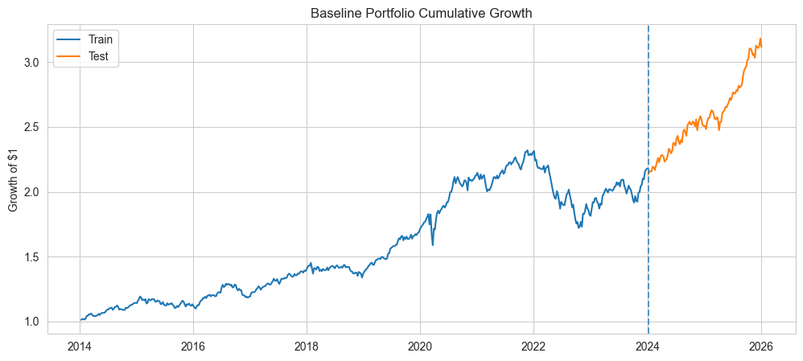

```python
# Plot Cumulative Returns
## Calculate cumulative values & revert back to original scale from log
train_cumulative = np.exp(np.cumsum(baseline_train_portfolio_returns))
test_cumulative = np.exp(np.cumsum(baseline_test_portfolio_returns))

## link from train to test for smooth plotting
test_cumulative_linked = train_cumulative[-1] * test_cumulative

## plot the growth curve to visually inspect the growth trend
plt.figure(figsize=(12, 5))
plt.plot(train_returns.index, train_cumulative, label="Train")
plt.plot(test_returns.index, test_cumulative_linked, label="Test")
plt.axvline(test_returns.index[0], linestyle="--", alpha=0.7)
plt.title("Baseline Portfolio Cumulative Growth")
plt.ylabel("Growth of $1")
plt.legend()
plt.show()
```

## 3. Bootstrap Analysis of Portfolio Weight Stability

Assess estimation uncertainty by using nonparametric bootstrapping.

Each bootstrap sample resamples histrorical returns wtih replacement & re-estimates mean and covariance to compute a bootstrap optimization solution.

The set of computed bootstrap optimization solutions become the empirical distribution of portfolio weights used to assess the stability of the optimizer.

CONTEXT:

The bootstrap results provide an empirical measure of estimation uncertainty in the plug-in optimizer.

If the portfolio weights vary substantially across bootstrap samples, this suggests that the optimized allocation is sensitive to sampling variation in the estimated mean returns and covariance matrix.

Assets that frequently receive near-zero weight or display wide bootstrap distributions can be interpreted as less stable components of the optimized portfolio.

```python
# Construct bootstrap

bootstrap_weights = []
train_array = train_returns.values ## convert to np array for easier application

np.random.seed(42426)
for _ in range(1000): ## for 1000 iterations
    # bootstrap sampling
    sample_idx = np.random.choice(len(train_array), size=len(train_array), replace=True) ## allow replacement
    bootstrap_sample = train_array[sample_idx]

    # mean & cov recalc
    mu_boot = bootstrap_sample.mean(axis=0)
    Sigma_boot = np.cov(bootstrap_sample, rowvar=False)

    # Solve optimization with bootstrap mean & cov
    weights_boot = solve_mean_variance_portfolio(mu_boot, Sigma_boot, gamma=10) ## same gamma level as baseline
    bootstrap_weights.append(weights_boot)

# Organize to df
bootstrap_weights_df = pd.DataFrame(np.array(bootstrap_weights), columns=train_returns.columns)
print(bootstrap_weights_df.shape)
display(bootstrap_weights_df.head().style.format({'Weight': '{:.5f}'}))
```

```
(1000, 6)
```

| Ticker | EEM | EFA | GLD | QQQ | SPY | TLT |
| --- | --- | --- | --- | --- | --- | --- |
| 0 | -0.000000 | 0.000000 | 0.063940 | 0.000000 | 0.449218 | 0.486843 |
| 1 | -0.000000 | -0.000000 | 0.194963 | 0.071415 | 0.311973 | 0.421650 |
| 2 | -0.000000 | -0.000000 | 0.510699 | 0.080518 | 0.244484 | 0.164300 |
| 3 | 0.000000 | 0.000000 | 0.242821 | 0.000000 | 0.463869 | 0.293310 |
| 4 | -0.000000 | -0.000000 | 0.246366 | 0.042140 | 0.343505 | 0.367989 |

This creates 1000 bootstrap distribution of 6 weights.

|  | Ticker | Baseline Weight | Bootstrap Mean | Bootstrap Std | Bootstrap 5% | Bootstrap 50% | Bootstrap 95% |
| --- | --- | --- | --- | --- | --- | --- | --- |
| 0 | TLT | 0.305579 | 0.299525 | 0.117572 | 0.101063 | 0.300831 | 0.485648 |
| 1 | GLD | 0.282966 | 0.281438 | 0.125336 | 0.064507 | 0.287946 | 0.490678 |
| 2 | QQQ | 0.229251 | 0.213535 | 0.153007 | -0.000000 | 0.223742 | 0.455287 |
| 3 | SPY | 0.182203 | 0.200928 | 0.177207 | -0.000000 | 0.168858 | 0.508315 |
| 4 | EFA | 0.000000 | 0.002479 | 0.017018 | -0.000000 | 0.000000 | 0.000000 |
| 5 | EEM | 0.000000 | 0.002096 | 0.013545 | -0.000000 | 0.000000 | 0.000000 |

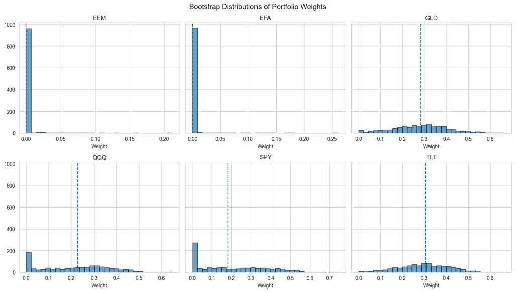

```python
# Summarize the bootstrap samples with distribution metrics
bootstrap_weight_summary = pd.DataFrame({
    "Ticker": bootstrap_weights_df.columns,
    "Baseline Weight": baseline_weights,
    "Bootstrap Mean": bootstrap_weights_df.mean().values,
    "Bootstrap Std": bootstrap_weights_df.std().values,
    "Bootstrap 5%": bootstrap_weights_df.quantile(0.05).values,
    "Bootstrap 50%": bootstrap_weights_df.quantile(0.50).values,
    "Bootstrap 95%": bootstrap_weights_df.quantile(0.95).values
}).sort_values("Baseline Weight", ascending=False).reset_index(drop=True)

display(bootstrap_weight_summary.style.format({'Weight': '{:.5f}'}))

# Plot distribution of weights for each asset
fig, axes = plt.subplots(2, 3, figsize=(14, 8), sharey=True)

for ax, ticker in zip(axes.flatten(), bootstrap_weights_df.columns):
    ax.hist(bootstrap_weights_df[ticker], bins=30, edgecolor="black", alpha=0.7)
    ax.axvline(baseline_weight_table.set_index("Ticker").loc[ticker, "Weight"], linestyle="--") ## shows original weight
    ax.set_title(ticker)
    ax.set_xlabel("Weight")

fig.suptitle("Bootstrap Distributions of Portfolio Weights", fontsize=14)
plt.tight_layout()
plt.show()
```

Aside from EEM an EFA who were originally estimated for zero-weight, assess general near-zero weight instances for each asset.

```python
# near_zero frequencies: indication of insability
zero_weight_frequency = (bootstrap_weights_df < 0.01).mean().reset_index()
zero_weight_frequency.columns = ["Ticker", "Bootstrap Weight < 1%"]
zero_weight_frequency = zero_weight_frequency.sort_values("Bootstrap Weight < 1%", ascending=False).reset_index(drop=True)

zero_weight_frequency
```

|  | Ticker | Bootstrap Weight < 1% |
| --- | --- | --- |
| 0 | EFA | 0.968 |
| 1 | EEM | 0.962 |
| 2 | SPY | 0.249 |
| 3 | QQQ | 0.175 |
| 4 | GLD | 0.020 |
| 5 | TLT | 0.006 |

```python
# weight instability (standard deviation of bootstrap distribution)
weight_instability = bootstrap_weights_df.std().sort_values(ascending=False).reset_index()
weight_instability.columns = ["Ticker", "Bootstrap Weight Std"]
weight_instability
```

|  | Ticker | Bootstrap Weight Std |
| --- | --- | --- |
| 0 | SPY | 0.177207 |
| 1 | QQQ | 0.153007 |
| 2 | GLD | 0.125336 |
| 3 | TLT | 0.117572 |
| 4 | EFA | 0.017018 |
| 5 | EEM | 0.013545 |

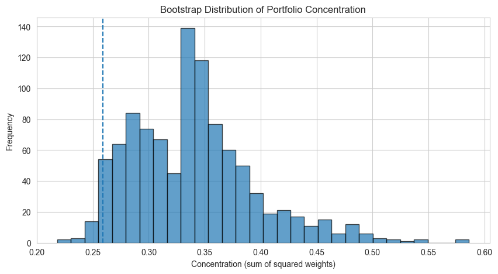

```python
# plot bootstrap distribution concentration & compare with original concentration value
bootstrap_concentration = np.sum(np.array(bootstrap_weights) ** 2, axis=1) # use sums of square to capture the diversification across 6 weights (same as baseline metric)
pd.Series(bootstrap_concentration).describe()

plt.figure(figsize=(10, 5))
plt.hist(bootstrap_concentration, bins=30, edgecolor="black", alpha=0.7)
plt.axvline(baseline_concentration, linestyle="--")
plt.title("Bootstrap Distribution of Portfolio Concentration")
plt.xlabel("Concentration (sum of squared weights)")
plt.ylabel("Frequency")
plt.show()
```

## 4. Bayesian Portfolio Analysis with Markov Chain Monte Carlo (MCMC)

Model ETF returns using a Bayesian multivariate normal framework.

Instead of using expected returns and covariance matrix as fixed input, estimate their posterior distribution using MCMC.

Posterior draws of the model parameters are then translated into posterior distribution of optimal portfolio weights.

The Bayesian model assumes that weekly ETF returns follow a multivariate normal distribution:

$$ r_t \sim \mathcal{N}(\mu, \Sigma) $$

where $\mu$ is the vector of expected returns and $\Sigma$ is the covariance matrix. Both are treated as unknown parameters and estimated jointly using MCMC.

Build a Bayesian model with priors from domain knowledge assumptions:

```python
# Fit Bayesian Model (posterior)

Y = train_returns.values
n_obs, n_assets = Y.shape

with pm.Model() as bayesian_model:
    mu = pm.Normal("mu", mu=0, sigma=0.05, shape=n_assets) ## this is the assumption about weekly informative prior: weekly expected return is likely near zero with small uncertainty (variation)
    chol, corr, sigmas = pm.LKJCholeskyCov( # prior on the covariance using Cholesky decomposition
        "chol_cov", # Chloesky factor of covariance matrix
        n=n_assets,
        eta=2, # LKJ prior on correlation (eta=2: not extreme correlation)
        sd_dist=pm.Exponential.dist(50.0) # prior on standard deviation. 1/50 = 0.02 assumes 2% weekly volatility
    )
    cov = pm.Deterministic("cov", chol @ chol.T) # reconstruct cov matrix using estimated Chloesky factor
    returns_obs = pm.MvNormal("returns_obs", mu=mu, chol=chol, observed=Y) # likelihood; model for observed returns
```

```python
# Sampling from posterior (takes 25 minutes)
with bayesian_model:
    trace = pm.sample(
        draws=1000, # actual samples entering the sample after tuning
        tune=1000,  # warm up (first walks to calibrate & gets discarded)
        chains=4,   # 4 independent walks
        target_accept=0.90, # the higher, the more careful
        random_seed=42426,
        return_inferencedata=True
    )
```

```
Initializing NUTS using jitter+adapt_diag...
Multiprocess sampling (4 chains in 4 jobs)
NUTS: [mu, chol_cov]
```

```
Output()
```

```
Sampling 4 chains for 1_000 tune and 1_000 draw iterations (4_000 + 4_000 draws total) took 1549 seconds.
```

```python
## summary for 6 means & covariance elements MCMC estimates
az.summary(trace, var_names=["mu", "cov"], round_to=4)
```

|  | mean | sd | hdi_3% | hdi_97% | mcse_mean | mcse_sd | ess_bulk | ess_tail | r_hat |
| --- | --- | --- | --- | --- | --- | --- | --- | --- | --- |
| mu[0] | 0.0004 | 0.0012 | -0.0018 | 0.0027 | 0.0 | 0.0 | 2581.9367 | 2854.5022 | 1.0007 |
| mu[1] | 0.0007 | 0.0010 | -0.0012 | 0.0027 | 0.0 | 0.0 | 2530.2848 | 2636.5664 | 1.0012 |
| mu[2] | 0.0009 | 0.0008 | -0.0007 | 0.0024 | 0.0 | 0.0 | 4337.1812 | 3160.0338 | 0.9998 |
| mu[3] | 0.0032 | 0.0012 | 0.0010 | 0.0054 | 0.0 | 0.0 | 2568.1169 | 2929.2228 | 1.0009 |
| mu[4] | 0.0022 | 0.0010 | 0.0001 | 0.0040 | 0.0 | 0.0 | 2400.3988 | 2655.0167 | 1.0011 |
| mu[5] | 0.0004 | 0.0009 | -0.0013 | 0.0021 | 0.0 | 0.0 | 4898.2108 | 2943.1796 | 0.9999 |
| cov[0, 0] | 0.0007 | 0.0000 | 0.0006 | 0.0008 | 0.0 | 0.0 | 3553.6039 | 3415.4793 | 1.0006 |
| cov[0, 1] | 0.0005 | 0.0000 | 0.0004 | 0.0006 | 0.0 | 0.0 | 2816.7813 | 2802.5533 | 1.0021 |
| cov[0, 2] | 0.0001 | 0.0000 | 0.0001 | 0.0002 | 0.0 | 0.0 | 4455.3676 | 3222.0726 | 0.9998 |
| cov[0, 3] | 0.0005 | 0.0000 | 0.0004 | 0.0005 | 0.0 | 0.0 | 2716.6545 | 2690.6274 | 1.0032 |
| cov[0, 4] | 0.0004 | 0.0000 | 0.0004 | 0.0005 | 0.0 | 0.0 | 2563.7407 | 2510.8477 | 1.0035 |
| cov[0, 5] | -0.0000 | 0.0000 | -0.0001 | 0.0000 | 0.0 | 0.0 | 4465.2443 | 2678.5094 | 1.0003 |
| cov[1, 0] | 0.0005 | 0.0000 | 0.0004 | 0.0006 | 0.0 | 0.0 | 2816.7813 | 2802.5533 | 1.0021 |
| cov[1, 1] | 0.0005 | 0.0000 | 0.0005 | 0.0006 | 0.0 | 0.0 | 2827.1972 | 2807.1911 | 1.0010 |
| cov[1, 2] | 0.0001 | 0.0000 | 0.0000 | 0.0001 | 0.0 | 0.0 | 4471.1436 | 3307.8587 | 1.0011 |
| cov[1, 3] | 0.0005 | 0.0000 | 0.0004 | 0.0005 | 0.0 | 0.0 | 2552.5706 | 2589.0407 | 1.0005 |
| cov[1, 4] | 0.0005 | 0.0000 | 0.0004 | 0.0005 | 0.0 | 0.0 | 2569.7722 | 2660.3616 | 1.0006 |
| cov[1, 5] | -0.0000 | 0.0000 | -0.0001 | 0.0000 | 0.0 | 0.0 | 4604.7710 | 3281.9921 | 1.0007 |
| cov[2, 0] | 0.0001 | 0.0000 | 0.0001 | 0.0002 | 0.0 | 0.0 | 4455.3676 | 3222.0726 | 0.9998 |
| cov[2, 1] | 0.0001 | 0.0000 | 0.0000 | 0.0001 | 0.0 | 0.0 | 4471.1436 | 3307.8587 | 1.0011 |
| cov[2, 2] | 0.0004 | 0.0000 | 0.0003 | 0.0004 | 0.0 | 0.0 | 4690.5861 | 2997.1373 | 1.0008 |
| cov[2, 3] | 0.0000 | 0.0000 | -0.0000 | 0.0001 | 0.0 | 0.0 | 4170.5703 | 3114.5487 | 1.0005 |
| cov[2, 4] | 0.0001 | 0.0000 | 0.0000 | 0.0001 | 0.0 | 0.0 | 4469.6213 | 3008.2887 | 1.0006 |
| cov[2, 5] | 0.0001 | 0.0000 | 0.0001 | 0.0002 | 0.0 | 0.0 | 4472.5462 | 2921.6823 | 1.0003 |
| cov[3, 0] | 0.0005 | 0.0000 | 0.0004 | 0.0005 | 0.0 | 0.0 | 2716.6545 | 2690.6274 | 1.0032 |
| cov[3, 1] | 0.0005 | 0.0000 | 0.0004 | 0.0005 | 0.0 | 0.0 | 2552.5706 | 2589.0407 | 1.0005 |
| cov[3, 2] | 0.0000 | 0.0000 | -0.0000 | 0.0001 | 0.0 | 0.0 | 4170.5703 | 3114.5487 | 1.0005 |
| cov[3, 3] | 0.0007 | 0.0000 | 0.0006 | 0.0008 | 0.0 | 0.0 | 2968.2876 | 2950.7768 | 1.0000 |
| cov[3, 4] | 0.0006 | 0.0000 | 0.0005 | 0.0006 | 0.0 | 0.0 | 2804.1270 | 2866.4963 | 1.0001 |
| cov[3, 5] | -0.0000 | 0.0000 | -0.0001 | 0.0000 | 0.0 | 0.0 | 4366.8393 | 2949.7477 | 1.0035 |
| cov[4, 0] | 0.0004 | 0.0000 | 0.0004 | 0.0005 | 0.0 | 0.0 | 2563.7407 | 2510.8477 | 1.0035 |
| cov[4, 1] | 0.0005 | 0.0000 | 0.0004 | 0.0005 | 0.0 | 0.0 | 2569.7722 | 2660.3616 | 1.0006 |
| cov[4, 2] | 0.0001 | 0.0000 | 0.0000 | 0.0001 | 0.0 | 0.0 | 4469.6213 | 3008.2887 | 1.0006 |
| cov[4, 3] | 0.0006 | 0.0000 | 0.0005 | 0.0006 | 0.0 | 0.0 | 2804.1270 | 2866.4963 | 1.0001 |
| cov[4, 4] | 0.0005 | 0.0000 | 0.0005 | 0.0006 | 0.0 | 0.0 | 2757.9858 | 2779.3877 | 1.0000 |
| cov[4, 5] | -0.0000 | 0.0000 | -0.0001 | -0.0000 | 0.0 | 0.0 | 4401.6682 | 3316.8397 | 1.0024 |
| cov[5, 0] | -0.0000 | 0.0000 | -0.0001 | 0.0000 | 0.0 | 0.0 | 4465.2443 | 2678.5094 | 1.0003 |
| cov[5, 1] | -0.0000 | 0.0000 | -0.0001 | 0.0000 | 0.0 | 0.0 | 4604.7710 | 3281.9921 | 1.0007 |
| cov[5, 2] | 0.0001 | 0.0000 | 0.0001 | 0.0002 | 0.0 | 0.0 | 4472.5462 | 2921.6823 | 1.0003 |
| cov[5, 3] | -0.0000 | 0.0000 | -0.0001 | 0.0000 | 0.0 | 0.0 | 4366.8393 | 2949.7477 | 1.0035 |
| cov[5, 4] | -0.0000 | 0.0000 | -0.0001 | -0.0000 | 0.0 | 0.0 | 4401.6682 | 3316.8397 | 1.0024 |
| cov[5, 5] | 0.0004 | 0.0000 | 0.0003 | 0.0004 | 0.0 | 0.0 | 4748.4744 | 3066.5101 | 0.9999 |

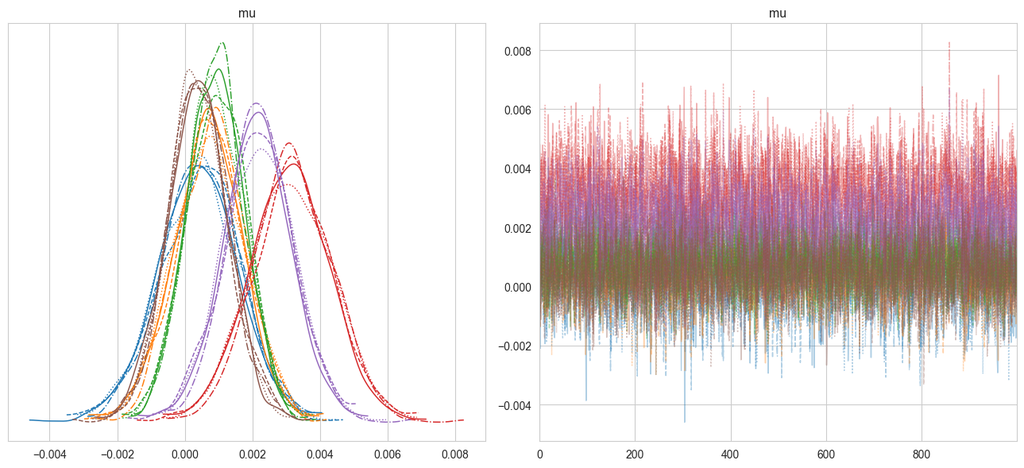

```python
# Trace plots for MCMC performance diagnostics
az.plot_trace(trace, var_names=["mu"], figsize=(13, 6))
plt.tight_layout()
plt.show()
```

The density plot (left) shows decent convergence on all 6 expected returns. The trace plot (right) is a bit difficult to interpret with all 6 lines overlapping, but overall seems to be consistent.

```python
# save posterior estimates
mu_draws = trace.posterior["mu"].stack(sample=("chain", "draw")).values.T
cov_draws = trace.posterior["cov"].stack(sample=("chain", "draw")).values.transpose(2, 0, 1)

mu_draws.shape, cov_draws.shape
```

```
((4000, 6), (4000, 6, 6))
```

```python
# Use posterior estimates to compute MCMC portfolio weights
n_posterior_portfolios = 500

posterior_weights = []

# Run optimization problem for each set of estimates of posterior
for i in range(n_posterior_portfolios):
    mu_post = mu_draws[i]
    Sigma_post = cov_draws[i]

    weights_post = solve_mean_variance_portfolio(mu_post, Sigma_post, gamma=10)
    posterior_weights.append(weights_post)

posterior_weights = np.array(posterior_weights)
posterior_weights_df = pd.DataFrame(posterior_weights, columns=train_returns.columns)
display(posterior_weights_df.head().style.format({'Weight': '{:.5f}'}))
```

| Ticker | EEM | EFA | GLD | QQQ | SPY | TLT |
| --- | --- | --- | --- | --- | --- | --- |
| 0 | 0.000000 | 0.000000 | 0.480754 | 0.294894 | 0.001305 | 0.223047 |
| 1 | 0.000000 | -0.000000 | 0.358614 | 0.218011 | 0.354369 | 0.069005 |
| 2 | -0.000000 | 0.000000 | 0.075625 | 0.134344 | 0.268129 | 0.521902 |
| 3 | -0.000000 | -0.000000 | 0.464801 | 0.125790 | 0.273677 | 0.135733 |
| 4 | -0.000000 | -0.000000 | 0.484578 | 0.307758 | 0.096463 | 0.111201 |

```python
# Create distribution summary for posterior weight in comparison to baseline & bootstrap means
posterior_weight_summary = pd.DataFrame({
    "Ticker": posterior_weights_df.columns,
    "Baseline Weight": baseline_weights,
    "Bootstrap Mean": bootstrap_weights_df.mean().values,
    "Posterior Mean": posterior_weights_df.mean().values,
    "Posterior Std": posterior_weights_df.std().values,
    "Posterior 5%": posterior_weights_df.quantile(0.05).values,
    "Posterior 50%": posterior_weights_df.quantile(0.50).values,
    "Posterior 95%": posterior_weights_df.quantile(0.95).values
}).sort_values("Posterior Mean", ascending=False).reset_index(drop=True)

posterior_weight_summary.style.format({'Weight': '{:.5f}'})
```

|  | Ticker | Baseline Weight | Bootstrap Mean | Posterior Mean | Posterior Std | Posterior 5% | Posterior 50% | Posterior 95% |
| --- | --- | --- | --- | --- | --- | --- | --- | --- |
| 0 | TLT | 0.305579 | 0.299525 | 0.297539 | 0.108787 | 0.111198 | 0.291633 | 0.479218 |
| 1 | GLD | 0.282966 | 0.281438 | 0.280349 | 0.110356 | 0.091804 | 0.284267 | 0.461047 |
| 2 | QQQ | 0.229251 | 0.213535 | 0.218583 | 0.148282 | -0.000000 | 0.217757 | 0.453994 |
| 3 | SPY | 0.182203 | 0.200928 | 0.199993 | 0.163563 | -0.000000 | 0.191662 | 0.462740 |
| 4 | EEM | 0.000000 | 0.002096 | 0.002372 | 0.013842 | -0.000000 | 0.000000 | 0.000000 |
| 5 | EFA | 0.000000 | 0.002479 | 0.001164 | 0.010874 | -0.000000 | 0.000000 | 0.000000 |

## 5. Comparisons and Posterior Predictions

Compare plug-in (baseline), bootstrap, and Bayesian (MCMC) using standard portfolio metrics.

Produce simple predictions using Bayesian model to assess its behavior. If the observed means and volatilities fall within the range of simulated values generated from the posterior, then the Bayesian model provides a broadly reasonable fit to the training data.

| Ticker | Plug-in | Bootstrap Mean | Bayesian Mean |
| --- | --- | --- | --- |
| EEM | 0.000000 | 0.002096 | 0.002372 |
| EFA | 0.000000 | 0.002479 | 0.001164 |
| GLD | 0.282966 | 0.281438 | 0.280349 |
| QQQ | 0.229251 | 0.213535 | 0.218583 |
| SPY | 0.182203 | 0.200928 | 0.199993 |
| TLT | 0.305579 | 0.299525 | 0.297539 |

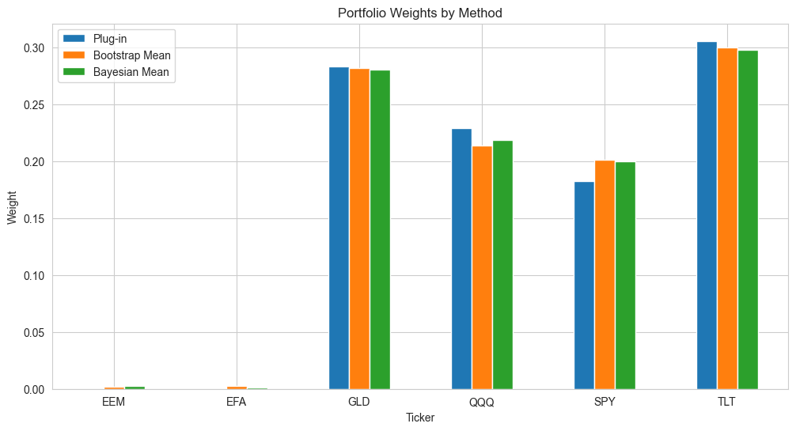

```python
# Extract Weight Estimates from each method

bootstrap_mean_weights = bootstrap_weights_df.mean().values # mean of bootstrap estimates
posterior_mean_weights = posterior_weights_df.mean().values # mean of MCMC estimates

method_weights = {
    "Plug-in": baseline_weights, # already summarized
    "Bootstrap Mean": bootstrap_mean_weights,
    "Bayesian Mean": posterior_mean_weights
}

# summarize into a simple matrix
weight_comparison = pd.DataFrame({
    "Ticker": train_returns.columns,
    "Plug-in": baseline_weights,
    "Bootstrap Mean": bootstrap_mean_weights,
    "Bayesian Mean": posterior_mean_weights
}).set_index("Ticker")

display(weight_comparison.style.format({'Weight': '{:.6f}'}))

# Create clustered bar chart to visualize differences
weight_comparison.plot(kind="bar", figsize=(12, 6))
plt.title("Portfolio Weights by Method")
plt.ylabel("Weight")
plt.xticks(rotation=0)
plt.show()
```

```python
# define concentration method (sums of square; same as bootstrap uncertainty metric)
def portfolio_concentration(weights):
    return np.sum(weights ** 2)

# compute train/holdout validation metrics (use above + previous metric defined in plug-in method)
comparison_rows = []

for method_name, weights in method_weights.items():
    train_portfolio = train_returns.values @ weights
    test_portfolio = test_returns.values @ weights

    train_stats = portfolio_summary_stats(train_portfolio)
    test_stats = portfolio_summary_stats(test_portfolio)

    comparison_rows.append({
        "Method": method_name,
        "Sample": "Train",
        "Mean Weekly Return": train_stats["Mean Weekly Return"],
        "Weekly Volatility": train_stats["Weekly Volatility"],
        "Sharpe Ratio": train_stats["Sharpe Ratio"],
        "Concentration": portfolio_concentration(weights)
    })

    comparison_rows.append({
        "Method": method_name,
        "Sample": "Test",
        "Mean Weekly Return": test_stats["Mean Weekly Return"],
        "Weekly Volatility": test_stats["Weekly Volatility"],
        "Sharpe Ratio": test_stats["Sharpe Ratio"],
        "Concentration": portfolio_concentration(weights)
    })

method_comparison = pd.DataFrame(comparison_rows)
method_comparison
```

|  | Method | Sample | Mean Weekly Return | Weekly Volatility | Sharpe Ratio | Concentration |
| --- | --- | --- | --- | --- | --- | --- |
| 0 | Plug-in | Train | 0.001496 | 0.014059 | 0.106380 | 0.259203 |
| 1 | Plug-in | Test | 0.003405 | 0.013106 | 0.259769 | 0.259203 |
| 2 | Bootstrap Mean | Train | 0.001486 | 0.014046 | 0.105776 | 0.254902 |
| 3 | Bootstrap Mean | Test | 0.003416 | 0.013066 | 0.261403 | 0.254902 |
| 4 | Bayesian Mean | Train | 0.001497 | 0.014084 | 0.106292 | 0.254908 |
| 5 | Bayesian Mean | Test | 0.003423 | 0.013119 | 0.260909 | 0.254908 |

|  | Method | Sample | Mean Weekly Return | Weekly Volatility | Sharpe Ratio | Concentration |
| --- | --- | --- | --- | --- | --- | --- |
| 0 | Bootstrap Mean | Test | 0.003416 | 0.013066 | 0.261403 | 0.254902 |
| 1 | Bayesian Mean | Test | 0.003423 | 0.013119 | 0.260909 | 0.254908 |
| 2 | Plug-in | Test | 0.003405 | 0.013106 | 0.259769 | 0.259203 |

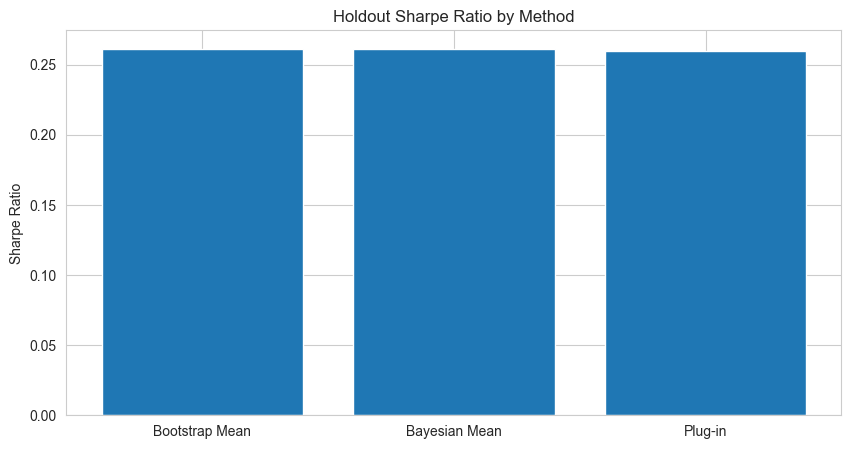

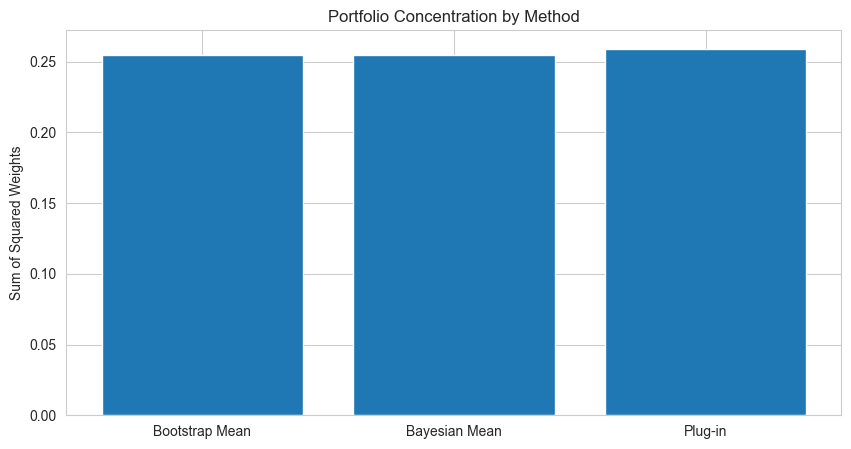

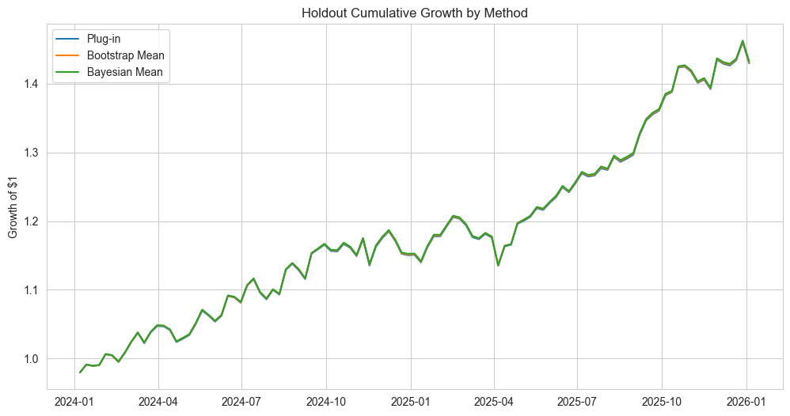

```python
# Look at only holdout (test) set & visualize
test_method_comparison = method_comparison[method_comparison["Sample"] == "Test"].copy()
test_method_comparison = test_method_comparison.sort_values("Sharpe Ratio", ascending=False).reset_index(drop=True)
display(test_method_comparison)

# Sharpe Ratio
plt.figure(figsize=(10, 5))
plt.bar(test_method_comparison["Method"], test_method_comparison["Sharpe Ratio"])
plt.title("Holdout Sharpe Ratio by Method")
plt.ylabel("Sharpe Ratio")
plt.show()

# Concentration (SS)
plt.figure(figsize=(10, 5))
plt.bar(test_method_comparison["Method"], test_method_comparison["Concentration"])
plt.title("Portfolio Concentration by Method")
plt.ylabel("Sum of Squared Weights")
plt.show()

# Growth Curve Fit
plt.figure(figsize=(12, 6))

for method_name, weights in method_weights.items():
    test_portfolio = test_returns.values @ weights
    test_cumulative = np.exp(np.cumsum(test_portfolio))
    plt.plot(test_returns.index, test_cumulative, label=method_name)

plt.title("Holdout Cumulative Growth by Method")
plt.ylabel("Growth of $1")
plt.legend()
plt.show()
```

Overall, all three provides about the same holdout set validation metrics. Their future fit also resemble each other with not much variations.

|  | Ticker | Observed Mean | Simulated Mean Average | Simulated Mean 5% | Simulated Mean 95% |
| --- | --- | --- | --- | --- | --- |
| 0 | EEM | 0.000414 | 0.000487 | -0.002144 | 0.003138 |
| 1 | EFA | 0.000717 | 0.000721 | -0.001667 | 0.003050 |
| 2 | GLD | 0.000905 | 0.000902 | -0.000973 | 0.003065 |
| 3 | QQQ | 0.003150 | 0.003139 | 0.000189 | 0.006107 |
| 4 | SPY | 0.002180 | 0.002195 | -0.000125 | 0.004743 |
| 5 | TLT | 0.000393 | 0.000375 | -0.001762 | 0.002639 |

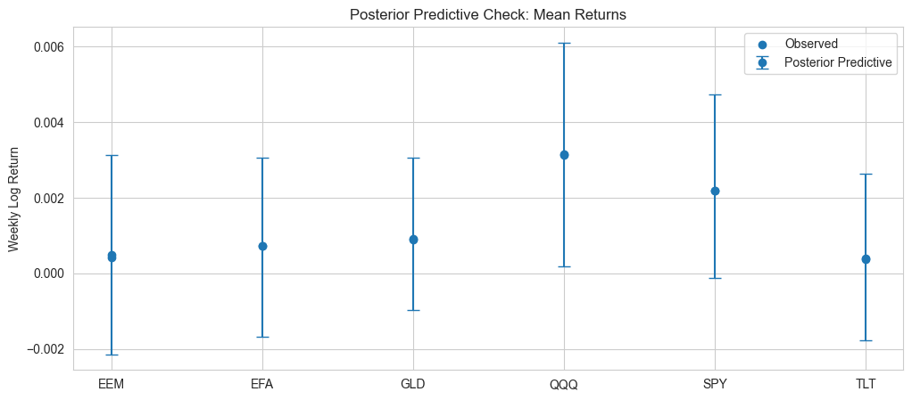

|  | Ticker | Observed Volatility | Simulated Volatility Average | Simulated Volatility 5% | Simulated Volatility 95% |
| --- | --- | --- | --- | --- | --- |
| 0 | EEM | 0.026913 | 0.026763 | 0.025113 | 0.028730 |
| 1 | EFA | 0.023607 | 0.023462 | 0.021902 | 0.025092 |
| 2 | GLD | 0.019395 | 0.019402 | 0.018300 | 0.020758 |
| 3 | QQQ | 0.027067 | 0.026848 | 0.024946 | 0.028713 |
| 4 | SPY | 0.023294 | 0.023045 | 0.021464 | 0.024758 |
| 5 | TLT | 0.019551 | 0.019534 | 0.018105 | 0.020886 |

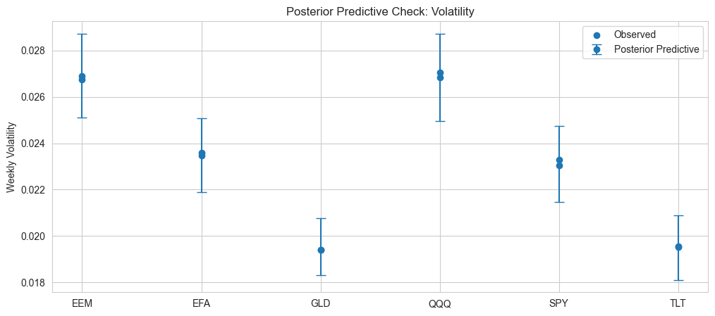

```python
# Check Predictive performance of Bayesian Model

n_ppc_draws = 200

posterior_predictive_returns = []

# Create predictions using MCMCs
for i in range(n_ppc_draws):
    simulated = np.random.multivariate_normal(
        mean=mu_draws[i], # posterior from MCMC
        cov=cov_draws[i],
        size=n_obs
    )
    posterior_predictive_returns.append(simulated)

posterior_predictive_returns = np.array(posterior_predictive_returns)

# Means
observed_mean_returns = train_returns.mean().values
simulated_mean_returns = posterior_predictive_returns.mean(axis=1)

ppc_mean_summary = pd.DataFrame({
    "Ticker": train_returns.columns,
    "Observed Mean": observed_mean_returns,
    "Simulated Mean Average": simulated_mean_returns.mean(axis=0),
    "Simulated Mean 5%": np.quantile(simulated_mean_returns, 0.05, axis=0),
    "Simulated Mean 95%": np.quantile(simulated_mean_returns, 0.95, axis=0)
})
display(ppc_mean_summary)

# Means Plot
plt.figure(figsize=(12, 5))
x = np.arange(len(train_returns.columns))

plt.errorbar(
    x,
    ppc_mean_summary["Simulated Mean Average"],
    yerr=[
        ppc_mean_summary["Simulated Mean Average"] - ppc_mean_summary["Simulated Mean 5%"],
        ppc_mean_summary["Simulated Mean 95%"] - ppc_mean_summary["Simulated Mean Average"]
    ],
    fmt="o",
    capsize=5,
    label="Posterior Predictive"
)

plt.scatter(x, ppc_mean_summary["Observed Mean"], label="Observed")
plt.xticks(x, train_returns.columns)
plt.title("Posterior Predictive Check: Mean Returns")
plt.ylabel("Weekly Log Return")
plt.legend()
plt.show()

# Cov (Volatility)
observed_volatility = train_returns.std().values
simulated_volatility = posterior_predictive_returns.std(axis=1)

ppc_vol_summary = pd.DataFrame({
    "Ticker": train_returns.columns,
    "Observed Volatility": observed_volatility,
    "Simulated Volatility Average": simulated_volatility.mean(axis=0),
    "Simulated Volatility 5%": np.quantile(simulated_volatility, 0.05, axis=0),
    "Simulated Volatility 95%": np.quantile(simulated_volatility, 0.95, axis=0)
})
display(ppc_vol_summary)

# Cov Plot
plt.figure(figsize=(12, 5))
x = np.arange(len(train_returns.columns))

plt.errorbar(
    x,
    ppc_vol_summary["Simulated Volatility Average"],
    yerr=[
        ppc_vol_summary["Simulated Volatility Average"] - ppc_vol_summary["Simulated Volatility 5%"],
        ppc_vol_summary["Simulated Volatility 95%"] - ppc_vol_summary["Simulated Volatility Average"]
    ],
    fmt="o",
    capsize=5,
    label="Posterior Predictive"
)

plt.scatter(x, ppc_vol_summary["Observed Volatility"], label="Observed")
plt.xticks(x, train_returns.columns)
plt.title("Posterior Predictive Check: Volatility")
plt.ylabel("Weekly Volatility")
plt.legend()
plt.show()
```